# Explore_bikeshare_data

### Explore Bike Share Data

For this project, your goal is to ask and answer three questions about the available bikeshare data from Washington, Chicago, and New York. This notebook can be submitted directly through the workspace when you are confident in your results.

You will be graded against the project [Rubric](https://review.udacity.com/#!/rubrics/2508/view) by a mentor after you have submitted. To get you started, you can use the template below, but feel free to be creative in your solutions!

```r
ny = read.csv('new_york_city.csv')
wash = read.csv('washington.csv')
chi = read.csv('chicago.csv')
```

```r
head(ny)
```

| X | Start.Time | End.Time | Trip.Duration | Start.Station | End.Station | User.Type | Gender | Birth.Year |
| --- | --- | --- | --- | --- | --- | --- | --- | --- |
| 5688089 | 2017-06-11 14:55:05 | 2017-06-11 15:08:21 | 795 | Suffolk St & Stanton St | W Broadway & Spring St | Subscriber | Male | 1998 |
| 4096714 | 2017-05-11 15:30:11 | 2017-05-11 15:41:43 | 692 | Lexington Ave & E 63 St | 1 Ave & E 78 St | Subscriber | Male | 1981 |
| 2173887 | 2017-03-29 13:26:26 | 2017-03-29 13:48:31 | 1325 | 1 Pl & Clinton St | Henry St & Degraw St | Subscriber | Male | 1987 |
| 3945638 | 2017-05-08 19:47:18 | 2017-05-08 19:59:01 | 703 | Barrow St & Hudson St | W 20 St & 8 Ave | Subscriber | Female | 1986 |
| 6208972 | 2017-06-21 07:49:16 | 2017-06-21 07:54:46 | 329 | 1 Ave & E 44 St | E 53 St & 3 Ave | Subscriber | Male | 1992 |
| 1285652 | 2017-02-22 18:55:24 | 2017-02-22 19:12:03 | 998 | State St & Smith St | Bond St & Fulton St | Subscriber | Male | 1986 |

```r
head(wash)
```

| X | Start.Time | End.Time | Trip.Duration | Start.Station | End.Station | User.Type |
| --- | --- | --- | --- | --- | --- | --- |
| 1621326 | 2017-06-21 08:36:34 | 2017-06-21 08:44:43 | 489.066 | 14th & Belmont St NW | 15th & K St NW | Subscriber |
| 482740 | 2017-03-11 10:40:00 | 2017-03-11 10:46:00 | 402.549 | Yuma St & Tenley Circle NW | Connecticut Ave & Yuma St NW | Subscriber |
| 1330037 | 2017-05-30 01:02:59 | 2017-05-30 01:13:37 | 637.251 | 17th St & Massachusetts Ave NW | 5th & K St NW | Subscriber |
| 665458 | 2017-04-02 07:48:35 | 2017-04-02 08:19:03 | 1827.341 | Constitution Ave & 2nd St NW/DOL | M St & Pennsylvania Ave NW | Customer |
| 1481135 | 2017-06-10 08:36:28 | 2017-06-10 09:02:17 | 1549.427 | Henry Bacon Dr & Lincoln Memorial Circle NW | Maine Ave & 7th St SW | Subscriber |
| 1148202 | 2017-05-14 07:18:18 | 2017-05-14 07:24:56 | 398.000 | 1st & K St SE | Eastern Market Metro / Pennsylvania Ave & 7th St SE | Subscriber |

```r
head(chi)
```

| X | Start.Time | End.Time | Trip.Duration | Start.Station | End.Station | User.Type | Gender | Birth.Year |
| --- | --- | --- | --- | --- | --- | --- | --- | --- |
| 1423854 | 2017-06-23 15:09:32 | 2017-06-23 15:14:53 | 321 | Wood St & Hubbard St | Damen Ave & Chicago Ave | Subscriber | Male | 1992 |
| 955915 | 2017-05-25 18:19:03 | 2017-05-25 18:45:53 | 1610 | Theater on the Lake | Sheffield Ave & Waveland Ave | Subscriber | Female | 1992 |
| 9031 | 2017-01-04 08:27:49 | 2017-01-04 08:34:45 | 416 | May St & Taylor St | Wood St & Taylor St | Subscriber | Male | 1981 |
| 304487 | 2017-03-06 13:49:38 | 2017-03-06 13:55:28 | 350 | Christiana Ave & Lawrence Ave | St. Louis Ave & Balmoral Ave | Subscriber | Male | 1986 |
| 45207 | 2017-01-17 14:53:07 | 2017-01-17 15:02:01 | 534 | Clark St & Randolph St | Desplaines St & Jackson Blvd | Subscriber | Male | 1975 |
| 1473887 | 2017-06-26 09:01:20 | 2017-06-26 09:11:06 | 586 | Clinton St & Washington Blvd | Canal St & Taylor St | Subscriber | Male | 1990 |

### Question 1

**How does user type vary across cities and does user behaviour change between subscribers and customers?**

```r
# Your solution code goes here
```

```
bshare$City: NY
             Customer Subscriber
       119       5558      49093
------------------------------------------------------------
bshare$City: WASH
             Customer Subscriber
         1      23450      65600
------------------------------------------------------------
bshare$City: CHI
             Customer Subscriber
         1       1746       6883
```

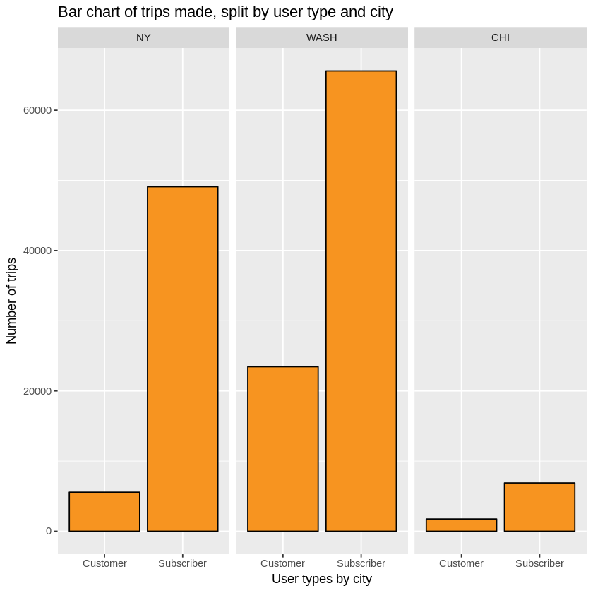

```
bshare[bshare$User.Type %in% c("Customer", "Subscriber"), ]$User.Type:
NULL
------------------------------------------------------------
bshare[bshare$User.Type %in% c("Customer", "Subscriber"), ]$User.Type: Customer
     Min.   1st Qu.    Median      Mean   3rd Qu.      Max.
    1.022    15.257    24.167    41.911    40.076 18143.900
------------------------------------------------------------
bshare[bshare$User.Type %in% c("Customer", "Subscriber"), ]$User.Type: Subscriber
    Min.  1st Qu.   Median     Mean  3rd Qu.     Max.
   1.000    5.869    9.459   12.325   15.245 2833.882
```

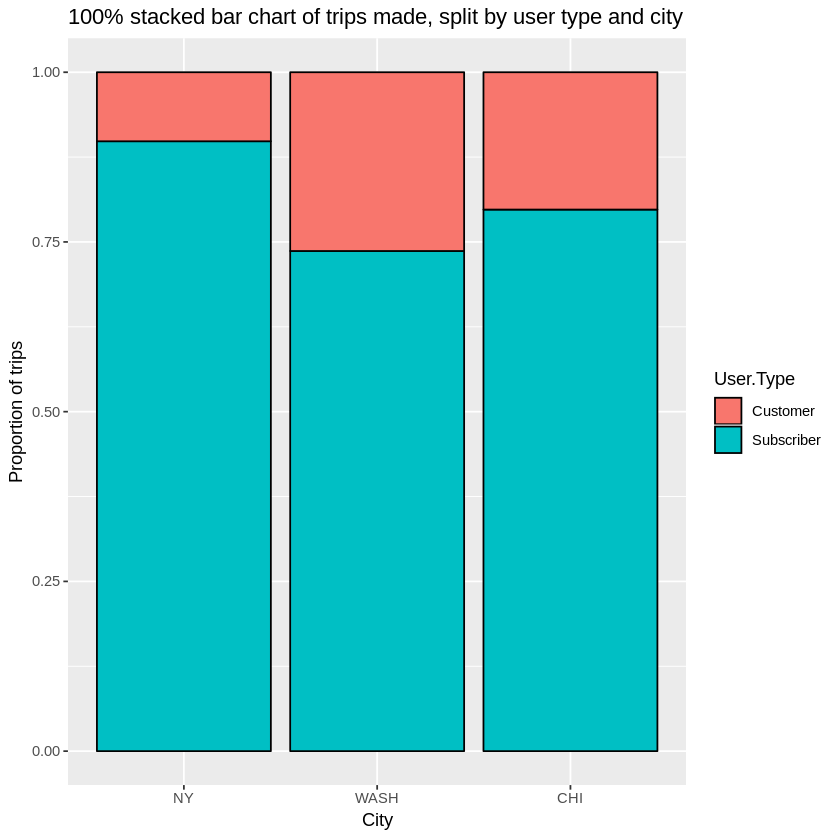

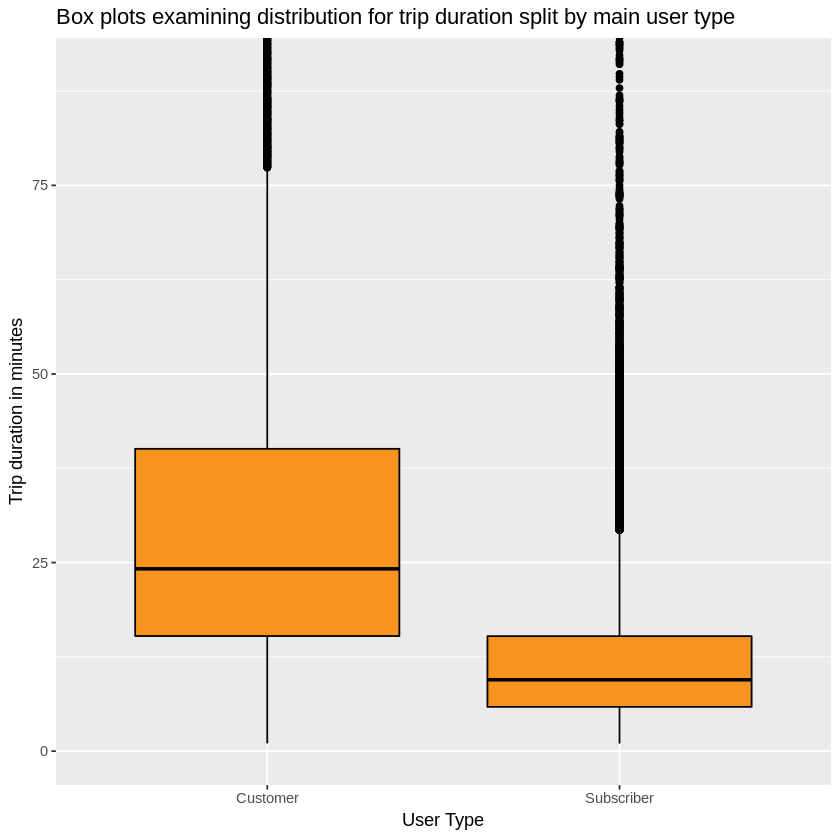

```r
# install ggplot2 package
library(ggplot2)

# define core variable names in separate matrix
variables <- c("X","Start.Time","End.Time","Trip.Duration","Start.Station","End.Station","User.Type")

#define final column names, including new city variable
col_names <- c(variables, "City")

#for workspace
ny = ny [variables]
wash = wash [variables]
chi = chi [variables]

# create a city column for each dataset
ny <- cbind(ny, "NY")
wash <- cbind(wash, "WASH")
chi <- cbind(chi, "CHI")

# rename columns
colnames(ny) <- col_names
colnames(wash) <- col_names
colnames(chi) <- col_names

# append all three datasets
bshare <- rbind(ny,wash,chi)

# first compute basic counts by city
by(bshare$User.Type, bshare$City, summary)

# second, plot a bar chart, removing 'dependent' counts and those without a user type
ggplot(data = bshare[bshare$User.Type %in% c("Customer","Subscriber"),], fill = "red") +
  geom_bar(mapping = aes(User.Type), color = 'black', fill = '#F79420') +
  facet_wrap(~City) +
  ggtitle('Bar chart of trips made, split by user type and city') +
  labs(x = 'User types by city', y = 'Number of trips')

# insight: Washington has the highest number of trips made by subscribers
# insight: Washington has the highest number of trips made by customers

# third, make stacked bars the same height to make it easy to compare proportions across cities
ggplot(data = bshare[bshare$User.Type %in% c("Customer","Subscriber"),]) +
  geom_bar(color = "black",
    mapping = aes(x = City, fill = User.Type),
    position = 'fill') +
  ggtitle('100% stacked bar chart of trips made, split by user type and city') +
  labs(x = 'City', y = 'Proportion of trips')

# insight: NY has highest proportion of trips made by subscribers
# insight: Washington has highest proportion of trips made by customers

# fourth, look at difference in travel duration between customers and subscribers, dividing trip duration by 60 so in minutes
by(bshare[bshare$User.Type %in% c("Customer","Subscriber"),]$Trip.Duration/60,
   bshare[bshare$User.Type %in% c("Customer","Subscriber"),]$User.Type,
   summary)

# use a box plot to look at difference in distribution using coord_cartesian to set the y limits and focus on the middle 50% rather than outliers
qplot(x = User.Type, y = Trip.Duration/60,
      data = bshare[bshare$User.Type %in% c("Customer","Subscriber"),],
      geom = 'boxplot',
      color = I('black'),
      fill = I('#F79420')) +
      coord_cartesian(ylim = c(0,90)) +
      labs(title="Box plots examining distribution for trip duration split by main user type",
      x="User Type", y="Trip duration in minutes")
```

### Insight:

**Washington has the highest number of trips made by both subscribers and customers. NY has highest proportion of trips made by subscribers. Washington has highest proportion of trips made by customers. Customers have a much higher mean/median for trip duration than subscribers.**

### Question 2

**Investigate into how extreme values impact on frequency plots and numerical summaries for trip duration**

```r
# Your solution code goes here
```

```
bshare$City: NY
     Min.   1st Qu.    Median      Mean   3rd Qu.      Max.      NA's
    1.017     6.133    10.167    15.060    17.517 18143.900         1
------------------------------------------------------------
bshare$City: WASH
     Min.   1st Qu.    Median      Mean   3rd Qu.      Max.      NA's
    1.005     6.848    11.783    20.566    20.554 15076.523         1
------------------------------------------------------------
bshare$City: CHI
    Min.  1st Qu.   Median     Mean  3rd Qu.     Max.
   1.000    6.571   11.167   15.620   18.650 1423.467
```

```
bshare$City: NY
   Min. 1st Qu.  Median    Mean 3rd Qu.    Max.    NA's
  1.967   6.133  10.167  12.726  17.517  31.955       1
------------------------------------------------------------
bshare$City: WASH
     Min.   1st Qu.    Median      Mean   3rd Qu.      Max.      NA's
    1.005     7.254    13.343    21.822    26.629 15076.523         1
------------------------------------------------------------
bshare$City: CHI
   Min. 1st Qu.  Median    Mean 3rd Qu.    Max.
   1.00    6.75   11.83   16.56   20.82 1423.47
```

[figure not shown]

```r
# install relevant packages
library(ggplot2)

# define core variable names in separate matrix
variables <- c("X","Start.Time","End.Time","Trip.Duration","Start.Station","End.Station","User.Type")

#define final column names, including new city variable
col_names <- c(variables, "City")

#for workspace
ny = ny [variables]
wash = wash [variables]
chi = chi [variables]

# create a city column for each dataset
ny <- cbind(ny, "NY")
wash <- cbind(wash, "WASH")
chi <- cbind(chi, "CHI")

# rename columns
colnames(ny) <- col_names
colnames(wash) <- col_names
colnames(chi) <- col_names

# append all three datasets
bshare <- rbind(ny,wash,chi)

# one, plot frequency graphs to see distribution split between different cities, converting seconds to minutes and zooming in since many extreme values
ggplot(data = subset(bshare, !is.na(Trip.Duration)), mapping = aes(x = Trip.Duration/60, color = City)) +
  geom_freqpoly(binwidth = 1) +
  coord_cartesian(xlim = c(0, 180)) +
  labs(title="Frequency polygons examining the distribution for trip duration, split by main user type",
       x="Trip duration in minutes", y="Frequency")

#insight: NY has more of a high peak than the other cities, but all 3 have the same right-skewed distribution meaning most trips have shorter durations but there is a long right tail and many outliers.

# two, compute numerical summary statistic for average trip duration split by city
by(bshare$Trip.Duration/60, bshare$City, summary)

# insight: similar median values across all three cities (10-12) but a higher mean (21) for Washington than NY (15) or Chicago (16)

# three, assume (for the sake of showcasing a loop) that the outliers/extreme values for trip duration need treating.
# to minimise the effects of extreme observations I will set all outliers to a specified percentile of the data

# four, set caps to the 1st and 99th percentiles
caps <- quantile(subset(bshare, !is.na(Trip.Duration))$Trip.Duration, probs=c(.01, .91), na.rm = T)

# five, use a loop to cap extreme values
idx = 1

for (num in subset(bshare, !is.na(Trip.Duration))$Trip.Duration){
  if (num < caps[1]){
    bshare$Trip.Duration[idx] = caps[1]
  }
  else if(num > caps[2]) {
    bshare$Trip.Duration[idx] = caps[2]
  }
  idx = idx + 1
}

# six, recompute numerical summary statistics for average trip duration split by city
by(bshare$Trip.Duration/60, bshare$City, summary)

# insight: median values remain as was, but mean values decrease - mostly for Washington (18), but also for NY (14) and Chicago (15).
```

### Question 3

**Does travel time differ over seasons and between weekends/weekdays?**

```r
# Your solution code goes here
```

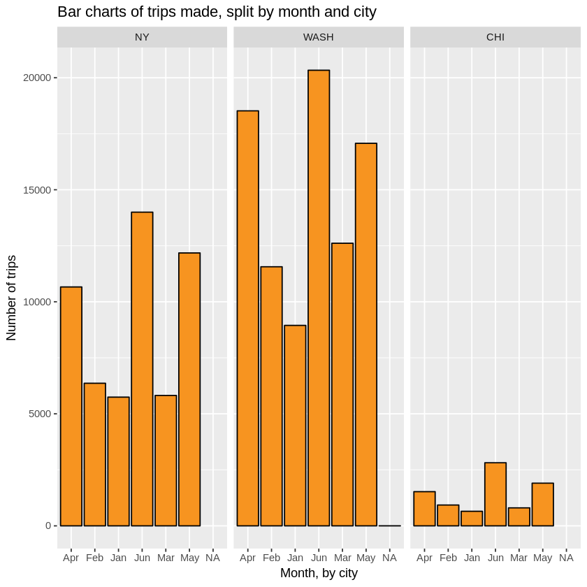

```
bshare$WDay: Fri
     Min.   1st Qu.    Median      Mean   3rd Qu.      Max.
    1.017     6.307    10.583    17.410    18.175 11278.112
------------------------------------------------------------
bshare$WDay: Mon
    Min.  1st Qu.   Median     Mean  3rd Qu.     Max.
   1.014    6.320   10.600   16.441   18.133 2401.714
------------------------------------------------------------
bshare$WDay: Sat
    Min.  1st Qu.   Median     Mean  3rd Qu.     Max.
   1.032    7.483   13.893   24.082   25.040 7437.117
------------------------------------------------------------
bshare$WDay: Sun
     Min.   1st Qu.    Median      Mean   3rd Qu.      Max.      NA's
    1.000     7.433    13.791    24.830    24.688 18143.900         1
------------------------------------------------------------
bshare$WDay: Thu
    Min.  1st Qu.   Median     Mean  3rd Qu.     Max.
   1.020    6.317   10.300   15.617   17.250 2902.733
------------------------------------------------------------
bshare$WDay: Tue
     Min.   1st Qu.    Median      Mean   3rd Qu.      Max.
    1.000     6.293    10.542    16.629    17.317 15076.523
------------------------------------------------------------
bshare$WDay: Wed
    Min.  1st Qu.   Median     Mean  3rd Qu.     Max.
   1.028    6.343   10.466   15.143   17.317 1844.133
```

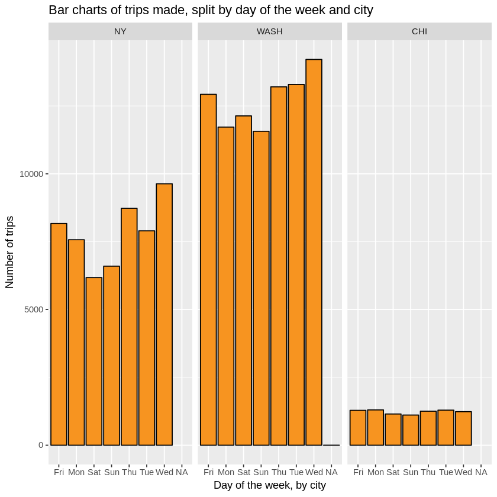

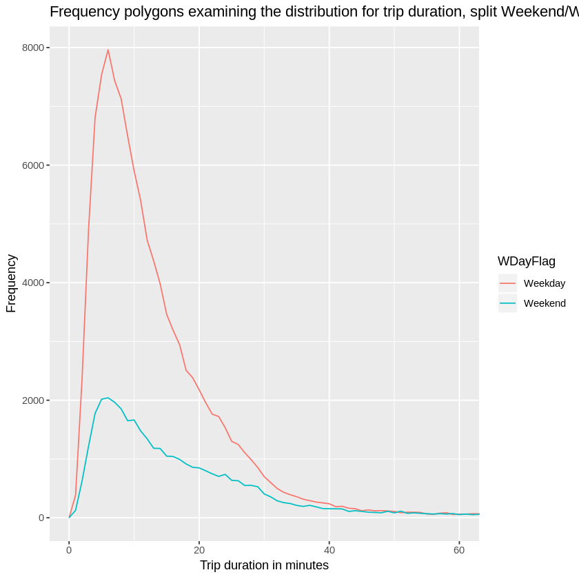

```r
# install relevant packages
library(ggplot2)

# define core variable names in separate matrix
variables <- c("X","Start.Time","End.Time","Trip.Duration","Start.Station","End.Station","User.Type")

#define final column names, including new city variable
col_names <- c(variables, "City")

#for workspace
ny = ny [variables]
wash = wash [variables]
chi = chi [variables]

# create a city column for each dataset
ny <- cbind(ny, "NY")
wash <- cbind(wash, "WASH")
chi <- cbind(chi, "CHI")

# rename columns
colnames(ny) <- col_names
colnames(wash) <- col_names
colnames(chi) <- col_names

# append all three datasets
bshare <- rbind(ny,wash,chi)

# draw out month/day date variable and flag for weekday/weekend
bshare$Month <-as.Date(bshare$Start.Time)
bshare$WDay <- as.Date(bshare$Start.Time)
bshare$Month <- format(bshare$Month,"%b")
bshare$WDay <- format(bshare$WDay,"%a")
bshare$WDayFlag <- ""

# one, plot barcharts to reveal trends in number of trips over months and days, split by city

# months
ggplot(data = bshare) +
  geom_bar(mapping = aes(x=Month), color = 'black', fill = '#F79420') +
  facet_wrap(bshare$City) +
  ggtitle('Bar charts of trips made, split by month and city') +
  labs(x = 'Month, by city', y = 'Number of trips')

# days
ggplot(data = bshare) +
  geom_bar(mapping = aes(x=WDay),color = 'black', fill = '#F79420') +
  facet_wrap(bshare$City) +
  ggtitle('Bar charts of trips made, split by day of the week and city') +
  labs(x = 'Day of the week, by city', y = 'Number of trips')

# insight: number of trips generally increase as the year progresses
# insight: number of trips generally increase in the mid week, peaking on Wed for both NY and Washington

# second, plot numerical summary stats to find out if the average trip length is different on different days
by(bshare$Trip.Duration/60, bshare$WDay, summary)

# insight: weekend effects exist for the avarage trip duration. Average values are higher than for the means taken Mon-Fri

# third, use graph to plot numerical summary stats (mean) over different days of the week
#ggplot(data = bshare,aes(x = bshare$WDay, y = bshare$Trip.Duration/60)) +
#  stat_summary(fun.y = mean, geom='point') +
#  coord_cartesian(ylim = c(0,25)) +
#  ggtitle('Chart of average trip duration over days of the week') +
#  labs(x = 'Day of the week, by city', y = 'Average trip duration in minutes')

# four, create a varible for Weekend/Weekday to allow further analysis
bshare$WDayFlag[bshare$WDay %in% c("Sun","Sat")] <- "Weekend"
bshare$WDayFlag[bshare$WDay %in% c("Mon","Tue","Wed","Thu","Fri")] <- "Weekday"

# five, plot frequency graphs to see distribution split between Weekend/Weekday
ggplot(data = subset(bshare, !is.na(Trip.Duration)), mapping = aes(x = subset(bshare, !is.na(Trip.Duration))$Trip.Duration/60, color = WDayFlag)) +
  geom_freqpoly(binwidth = 1) +
  coord_cartesian(xlim = c(0, 60)) +
  labs(title="Frequency polygons examining the distribution for trip duration, split Weekend/Weekday",
       x="Trip duration in minutes", y="Frequency")

# insight: the distribution for weekdays has more of a high peak, whereas the distribution for weekend rides is not as extreme (though still right tailed)
# this suggest weekday rides are more often shorter than weekend rides.
```

### Insight:

**Number of trips generally increase as the year progresses. Number of trips generally increase in the mid week, peaking on Wed for both NY and Washington. Weekend effects exist for the average trip duration. Average values are higher for weekend days than for the means taken Mon-Fri. The distribution for weekdays has more of a high peak, whereas the distribution for weekend rides is not as extreme (though still right tailed) - this suggest weekday rides are more often shorter than weekend rides.**

## Finishing Up

> Congratulations! You have reached the end of the Explore Bikeshare Data Project. You should be very proud of all you have accomplished!

> **Tip**: Once you are satisfied with your work here, check over your report to make sure that it is satisfies all the areas of the [rubric](https://review.udacity.com/#!/rubrics/2508/view).

## Directions to Submit

> Before you submit your project, you need to create a .html or .pdf version of this notebook in the workspace here. To do that, run the code cell below. If it worked correctly, you should get a return code of 0, and you should see the generated .html file in the workspace directory (click on the orange Jupyter icon in the upper left).

> Alternatively, you can download this report as .html via the **File** > **Download as** submenu, and then manually upload it into the workspace directory by clicking on the orange Jupyter icon in the upper left, then using the Upload button.

> Once you've done this, you can submit your project by clicking on the "Submit Project" button in the lower right here. This will create and submit a zip file with this .ipynb doc and the .html or .pdf version you created. Congratulations!

```r
system('python -m nbconvert Explore_bikeshare_data.ipynb')
```